# Problem Set 5 Quiz: Answer Key

Questions 2 through 4 and 6 through 9 are written answers. Choose **one answer** for each multiple-choice question. Each question is worth 1 point.

In PS5 the outcome was the **percent undervote**: the share of ballots that voted in the base race but skipped the Senate race. The table gives the four quantities from PS5, rounded. A negative number means more votes were cast in the Senate race than in the base race.

|  | 2016 | 2018 |
| --- | --- | --- |
| Broward County | 1.5 | 2.9 |
| Other 66 Florida counties (average) | 2.4 | -1.3 |

## Question 1

In PS5 we treated the Broward County story as if it were an experiment. What is the **treatment**?

**A. Broward County’s ballot design, which placed the Senate race under the instructions.**

2. Casting a vote in the governor’s race but not in the Senate race on the same ballot.
3. Being one of the largest and most Democratic counties in the state of Florida.
4. Rick Scott’s 10,033-vote statewide victory over Bill Nelson in the Senate race.

The treatment is the thing whose effect we want to know, the ballot design, and Broward is the one treated unit; the other 66 counties are the comparison. B is the outcome (the undervote), not the treatment. C is a characteristic of Broward that could confound the cross-section comparison, which is why the before-and-after and difference-in-differences comparisons were also used. D is the election result that motivated the question.

## Question 2

Using the labels in the table, write the formula for the **cross-section** comparison of Broward’s 2018 undervote, then calculate it in percentage points.

**Answer.** Cross-section = Broward 2018 - Other counties 2018 = 2.9 - (-1.3) = **4.2 percentage points**. Broward’s undervote in 2018 was 4.2 points higher than the average of the other counties. Full credit needs the subtraction of the two 2018 numbers; the most common error is 2.9 - 1.3 = 1.6, which drops the sign on the other counties’ average.

## Question 3

Using the labels in the table, write the formula for the **before-and-after** comparison, then calculate it in percentage points.

**Answer.** Before-and-after = Broward 2018 - Broward 2016 = 2.9 - 1.5 = **1.4 percentage points**. Broward’s undervote rose by 1.4 points between 2016 and 2018. Only Broward’s two numbers are used; the other counties play no role.

## Question 4

Using the labels in the table, write the formula for the **difference-in-differences**, then calculate it in percentage points.

**Answer.** Difference-in-differences = (Broward 2018 - Broward 2016) - (Other 2018 - Other 2016) = (2.9 - 1.5) - (-1.3 - 2.4) = 1.4 - (-3.7) = **5.1 percentage points**. Broward’s undervote rose by 1.4 points while the other counties’ undervote fell by 3.7 points, so Broward’s change was 5.1 points larger than the change elsewhere. Full credit for either the change-by-group form above or the equivalent (Broward 2018 - Other 2018) - (Broward 2016 - Other 2016) = 4.2 - (-0.9) = 5.1. The number alone without a formula earns half credit.

## Question 5

What must be true for the difference-in-differences in Question 4 to equal the causal effect of the ballot design?

1. Broward and the other counties must have had the same undervote in 2016, before the ballot.

**B. Absent the bad ballot, Broward’s undervote would have changed by as much as the other counties’.**

3. Broward must be comparable to the other counties in every way other than its 2018 ballot.
4. Nothing other than the ballot can have changed in Broward between the 2016 and 2018 elections.

This is the parallel-trends assumption. A is not required: difference-in-differences does not need the groups to start at the same level. C is the assumption behind the cross-section comparison, and D is the assumption behind the before-and-after comparison.

## Question 6

Each point in the plot is a Florida county. The line is the 45-degree line.

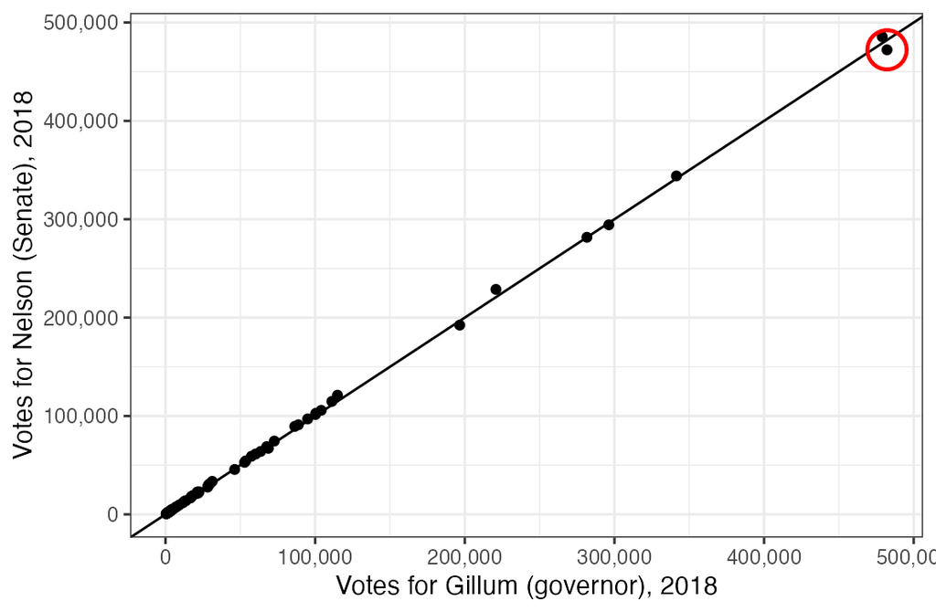

What does it mean for a county to be on the 45-degree line?

**Answer.** A county on the line cast exactly as many votes for Nelson (Senate) as for Gillum (governor): the two Democrats on the same 2018 ballot received the same number of votes there. Nearly every county is on or very close to the line.

## Question 7

Circle Broward county.

**Answer.** Broward is the circled point below the line at the top right, near 480,000 Gillum votes. Nelson received about 10,000 fewer votes than Gillum there (472,239 versus 482,152), which is what we would expect if voters who voted for Gillum missed the Senate race. The other large county, Miami-Dade, sits slightly above the line.

## Question 8

Here is the regression from PS5, which predicts each county’s votes for Nelson from its votes for Gillum.

```r
fl.reg = lm(SenDemVote2018 ~ GovDemVote2018, data = florida)
fl.reg
```

```
Call:
lm(formula = SenDemVote2018 ~ GovDemVote2018, data = florida)

Coefficients:
   (Intercept)  GovDemVote2018
      704.9200          0.9996
```

Interpret the **slope** in terms of votes.

**Answer.** The slope is 0.9996: each additional vote for Gillum in a county is associated with 0.9996 additional votes for Nelson, essentially one for one. A slope of essentially 1 means the regression line is almost exactly the 45-degree line: across Florida counties, Nelson and Gillum received nearly identical vote totals. The intercept of 705 is the predicted Nelson vote in a county with zero Gillum votes, which no county has; it is not meaningful on its own.

## Question 9

If a county cast 1,000 more votes for Gillum, how many more votes for Nelson does the regression predict?

**Answer.** About **1,000 more votes for Nelson** (0.9996 $\times$ 1,000 = 999.6). Full credit for 1,000 or 999.6.

## Question 10

Our regression predicted that Broward would have about 10,000 more votes for Nelson than we observe. What can we conclude from this?

1. The Broward ballot affected the outcome of the Senate race.
2. Voting fraud occurred in Broward County in the Senate race.
3. Florida has real problems with how it runs its elections.

**D. What happened in Broward differs from what happened elsewhere.**

The regression describes what the other counties predict for Broward; the gap between prediction and observation shows only that Broward is different from the rest of the state. Whether the ballot is the reason requires the argument about confounders from Part C, not the regression. A claims a cause and an effect on the outcome that the regression alone cannot establish, and B and C go well beyond what the data show.